# Predicting Fire Area Damage

For this assignment, we will be using linear regresion to forecase fire area damage. We will leverage the [Forest Fires Data Set](https://archive.ics.uci.edu/ml/datasets/Forest+Fires) to solve this problem. Additional information regarding this work can be found [Cortez and Morais, 2007](http://www3.dsi.uminho.pt/pcortez/fires.pdf).

Attribute information:

For more information, read [Cortez and Morais, 2007].

1. X - x-axis spatial coordinate within the Montesinho park map: 1 to 9
2. Y - y-axis spatial coordinate within the Montesinho park map: 2 to 9
3. month - month of the year: "jan" to "dec"
4. day - day of the week: "mon" to "sun"
5. FFMC - FFMC index from the FWI system: 18.7 to 96.20
6. DMC - DMC index from the FWI system: 1.1 to 291.3
7. DC - DC index from the FWI system: 7.9 to 860.6
8. ISI - ISI index from the FWI system: 0.0 to 56.10
9. temp - temperature in Celsius degrees: 2.2 to 33.30
10. RH - relative humidity in %: 15.0 to 100
11. wind - wind speed in km/h: 0.40 to 9.40
12. rain - outside rain in mm/m2 : 0.0 to 6.4
13. area - the burned area of the forest (in ha): 0.00 to 1090.84 (this output variable is very skewed towards 0.0, thus it may make sense to model with the logarithm transform).

```python
import pandas as pd
forestfires = pd.read_csv('forestfires.csv')
forestfires.head(10)
```

|  | X | Y | month | day | FFMC | DMC | DC | ISI | temp | RH | wind | rain | area |
| --- | --- | --- | --- | --- | --- | --- | --- | --- | --- | --- | --- | --- | --- |
| 0 | 7 | 5 | mar | fri | 86.2 | 26.2 | 94.3 | 5.1 | 8.2 | 51 | 6.7 | 0.0 | 0.0 |
| 1 | 7 | 4 | oct | tue | 90.6 | 35.4 | 669.1 | 6.7 | 18.0 | 33 | 0.9 | 0.0 | 0.0 |
| 2 | 7 | 4 | oct | sat | 90.6 | 43.7 | 686.9 | 6.7 | 14.6 | 33 | 1.3 | 0.0 | 0.0 |
| 3 | 8 | 6 | mar | fri | 91.7 | 33.3 | 77.5 | 9.0 | 8.3 | 97 | 4.0 | 0.2 | 0.0 |
| 4 | 8 | 6 | mar | sun | 89.3 | 51.3 | 102.2 | 9.6 | 11.4 | 99 | 1.8 | 0.0 | 0.0 |
| 5 | 8 | 6 | aug | sun | 92.3 | 85.3 | 488.0 | 14.7 | 22.2 | 29 | 5.4 | 0.0 | 0.0 |
| 6 | 8 | 6 | aug | mon | 92.3 | 88.9 | 495.6 | 8.5 | 24.1 | 27 | 3.1 | 0.0 | 0.0 |
| 7 | 8 | 6 | aug | mon | 91.5 | 145.4 | 608.2 | 10.7 | 8.0 | 86 | 2.2 | 0.0 | 0.0 |
| 8 | 8 | 6 | sep | tue | 91.0 | 129.5 | 692.6 | 7.0 | 13.1 | 63 | 5.4 | 0.0 | 0.0 |
| 9 | 7 | 5 | sep | sat | 92.5 | 88.0 | 698.6 | 7.1 | 22.8 | 40 | 4.0 | 0.0 | 0.0 |

Question 1.1: Using the [describe](https://pandas.pydata.org/pandas-docs/stable/reference/api/pandas.DataFrame.describe.html) method, provide the summary statistics of the data

```python
forestfires.describe()
```

|  | X | Y | FFMC | DMC | DC | ISI | temp | RH | wind | rain | area |
| --- | --- | --- | --- | --- | --- | --- | --- | --- | --- | --- | --- |
| count | 517.000000 | 517.000000 | 517.000000 | 517.000000 | 517.000000 | 517.000000 | 517.000000 | 517.000000 | 517.000000 | 517.000000 | 517.000000 |
| mean | 4.669246 | 4.299807 | 90.644681 | 110.872340 | 547.940039 | 9.021663 | 18.889168 | 44.288201 | 4.017602 | 0.021663 | 12.847292 |
| std | 2.313778 | 1.229900 | 5.520111 | 64.046482 | 248.066192 | 4.559477 | 5.806625 | 16.317469 | 1.791653 | 0.295959 | 63.655818 |
| min | 1.000000 | 2.000000 | 18.700000 | 1.100000 | 7.900000 | 0.000000 | 2.200000 | 15.000000 | 0.400000 | 0.000000 | 0.000000 |
| 25% | 3.000000 | 4.000000 | 90.200000 | 68.600000 | 437.700000 | 6.500000 | 15.500000 | 33.000000 | 2.700000 | 0.000000 | 0.000000 |
| 50% | 4.000000 | 4.000000 | 91.600000 | 108.300000 | 664.200000 | 8.400000 | 19.300000 | 42.000000 | 4.000000 | 0.000000 | 0.520000 |
| 75% | 7.000000 | 5.000000 | 92.900000 | 142.400000 | 713.900000 | 10.800000 | 22.800000 | 53.000000 | 4.900000 | 0.000000 | 6.570000 |
| max | 9.000000 | 9.000000 | 96.200000 | 291.300000 | 860.600000 | 56.100000 | 33.300000 | 100.000000 | 9.400000 | 6.400000 | 1090.840000 |

Question 1.2: Apply log(area+1) to the data

```python
import numpy as np
# I believe this is what I want
# https://numpy.org/doc/stable/reference/generated/numpy.log1p.html#numpy.log1p
# doc says: Calculates log(1 + x)
forestfires['logarea'] = np.log1p(forestfires['area'])
forestfires.describe()
```

|  | X | Y | FFMC | DMC | DC | ISI | temp | RH | wind | rain | area | logarea |
| --- | --- | --- | --- | --- | --- | --- | --- | --- | --- | --- | --- | --- |
| count | 517.000000 | 517.000000 | 517.000000 | 517.000000 | 517.000000 | 517.000000 | 517.000000 | 517.000000 | 517.000000 | 517.000000 | 517.000000 | 517.000000 |
| mean | 4.669246 | 4.299807 | 90.644681 | 110.872340 | 547.940039 | 9.021663 | 18.889168 | 44.288201 | 4.017602 | 0.021663 | 12.847292 | 1.111026 |
| std | 2.313778 | 1.229900 | 5.520111 | 64.046482 | 248.066192 | 4.559477 | 5.806625 | 16.317469 | 1.791653 | 0.295959 | 63.655818 | 1.398436 |
| min | 1.000000 | 2.000000 | 18.700000 | 1.100000 | 7.900000 | 0.000000 | 2.200000 | 15.000000 | 0.400000 | 0.000000 | 0.000000 | 0.000000 |
| 25% | 3.000000 | 4.000000 | 90.200000 | 68.600000 | 437.700000 | 6.500000 | 15.500000 | 33.000000 | 2.700000 | 0.000000 | 0.000000 | 0.000000 |
| 50% | 4.000000 | 4.000000 | 91.600000 | 108.300000 | 664.200000 | 8.400000 | 19.300000 | 42.000000 | 4.000000 | 0.000000 | 0.520000 | 0.418710 |
| 75% | 7.000000 | 5.000000 | 92.900000 | 142.400000 | 713.900000 | 10.800000 | 22.800000 | 53.000000 | 4.900000 | 0.000000 | 6.570000 | 2.024193 |
| max | 9.000000 | 9.000000 | 96.200000 | 291.300000 | 860.600000 | 56.100000 | 33.300000 | 100.000000 | 9.400000 | 6.400000 | 1090.840000 | 6.995620 |

Question 2.1: Visually explore the data using pairplot.

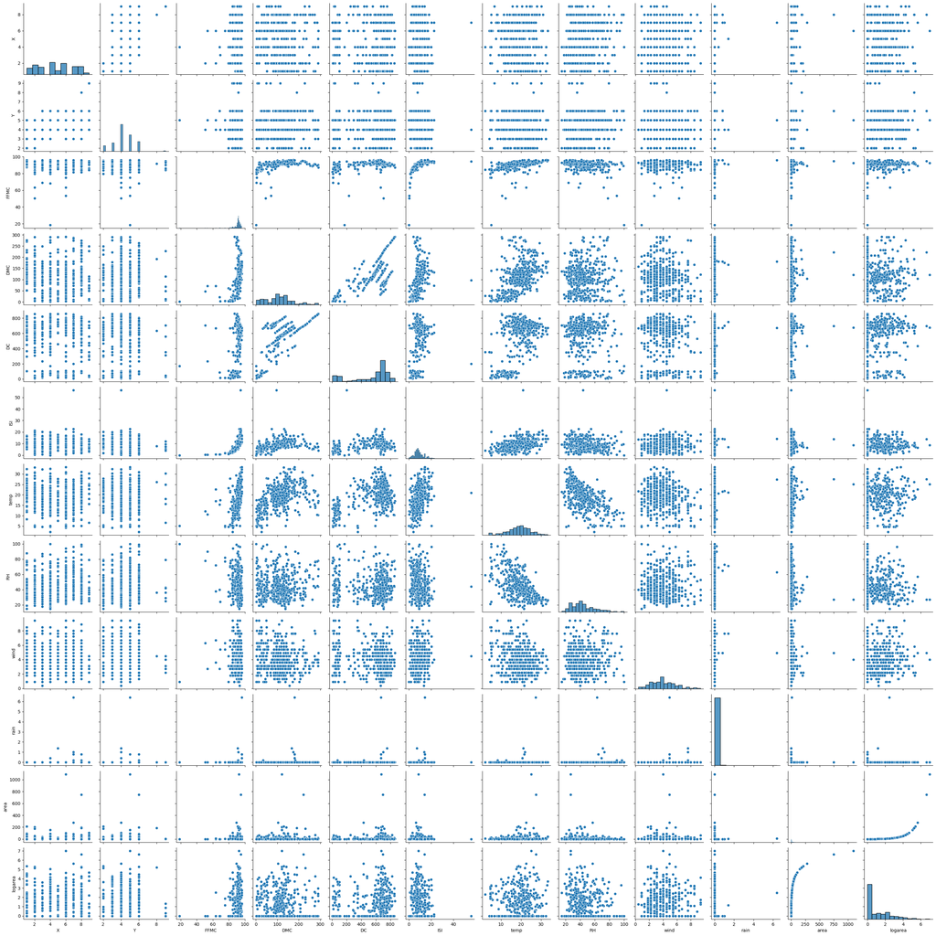

```python
import seaborn as sns
sns.pairplot(forestfires)
```

Question 2.2: Zoom in at the rain vs area by plotting the scatter plot. What do you conclude?

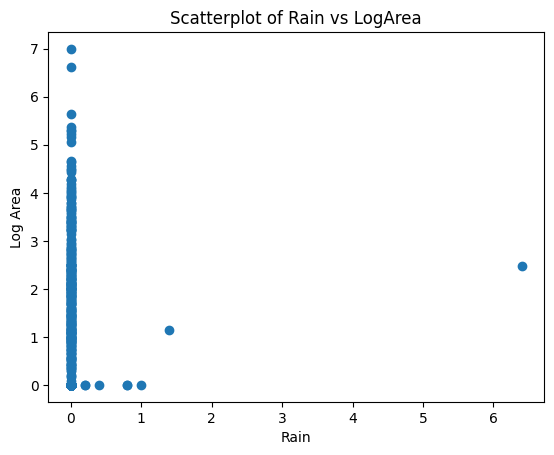

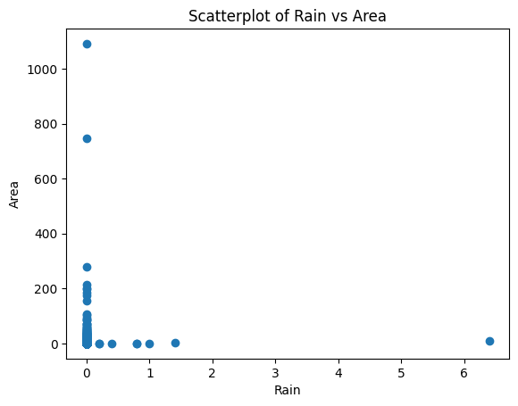

```python
import matplotlib.pyplot as plt

plt.scatter(forestfires['rain'], forestfires['logarea'])
plt.xlabel('Rain')
plt.ylabel('Log Area')
plt.title('Scatterplot of Rain vs LogArea')
plt.show()

plt.scatter(forestfires['rain'], forestfires['area'])
plt.xlabel('Rain')
plt.ylabel('Area')
plt.title('Scatterplot of Rain vs Area')
plt.show()
```

There isn't many instances where it rains during the fire, but when it does, it limits the area spread given that we remove the two outlier points where rain is greater than 1mm

Question 4.1: Develop a simple linear regression model, relating area with rain and wind only. Calculate the predict values based on test data.

```python
from sklearn.linear_model import LinearRegression
from sklearn.model_selection import train_test_split

# start with the original data
forestfires = pd.read_csv('forestfires.csv')
forestfires['logarea'] = np.log1p(forestfires['area'])

# Split the data into training and testing sets
X = forestfires[['rain', 'wind']]


y = forestfires['logarea']
C = forestfires[['rain', 'wind', 'logarea']]
print(C.cov()) # wanted to see the covariance matrix and which X is more correlated with Y
X_train, X_test, y_train, y_test = train_test_split(X, y, test_size=0.2, random_state=53)

# Create an instance of the LinearRegression model
model = LinearRegression()

# Fit the model to the training data
model.fit(X_train, y_train)

# Predict the target variable using the testing data
y_pred = model.predict(X_test)
```

```
             rain      wind   logarea
rain     0.087592  0.032409  0.009648
wind     0.032409  3.210019  0.167803
logarea  0.009648  0.167803  1.955623
```

Question 4.2: Calculate the mean squared error of predict results.

```python
from sklearn.metrics import mean_squared_error

# Calculate the mean squared error
mse = mean_squared_error(y_test, y_pred)
mse
```

```
1.4611816249539966
```

Question 5.1: Develop a linear regression model, relating area with all features. Calculate the predict values based on test data.

```python
X = forestfires.drop('area', axis=1) # I'm taking every column except area/logarea since that is our dependent variable
X = X.drop('logarea', axis=1)
# Convert the categorical data into numbers otherwise the regression crashes on string values
X['month'] = X['month'].map({'jan': 1, 'feb': 2, 'mar': 3, 'apr': 4, 'may': 5, 'jun': 6, 'jul': 7, 'aug': 8, 'sep': 9, 'oct': 10, 'nov': 11, 'dec': 12})
X['day'] = X['day'].map({'mon': 1, 'tue': 2, 'wed': 3, 'thu': 4, 'fri': 5, 'sat': 6, 'sun': 7})
#X.head()
y = forestfires['logarea']

X_train, X_test, y_train, y_test = train_test_split(X, y, test_size=0.2, random_state=53)

# Create an instance of the LinearRegression model
model = LinearRegression()

# Fit the model to the training data
model.fit(X_train, y_train)

# Predict the target variable using the testing data
y_pred = model.predict(X_test)
```

Question 5.2: Calculate the mean squared error of predict results.

```python
# Calculate the mean squared error
mse = mean_squared_error(y_test, y_pred)
print(mse)
```

```
1.548701688617019
```

Below I decided to try encoding month differently based on some comments I read in StackExchange about encoding times that are cyclical in nature. The thought being that since Jan and December are similar in weather, they should also have similar values. So I decided to encode the hottest months of the year as 6 and then subtract one from those as we go toward Jan/December.

'jan': 1, 'feb': 1, 'mar': 2, 'apr': 3, 'may': 4, 'jun': 5, 'jul': 6, 'aug': 5, 'sep': 4, 'oct': 3, 'nov': 2, 'dec': 1

1. The first experiment was to just do one-hot encoding of Day/Month data. (this is the one left uncommented as it performed best)
2. Second I did my less naive mapping of months to numeric values as described above. MSE was worse in this case.
3. Finally I tried dropping month/day data completely. This also did not perform as well as one-hot encoding them

```python
import pandas as pd
import numpy as np
forestfires = pd.read_csv('forestfires.csv')
forestfires['area'] = np.log1p(forestfires['area'])

# 1. perform one-hot encoding on the categorical data of month and day
forestfires = pd.get_dummies(forestfires, columns=['month', 'day'])

# 2. Tried mapping month and day to "non-naive" numerical values
#forestfires['month'] = forestfires['month'].map({'jan': 1, 'feb': 1, 'mar': 2, 'apr': 3, 'may': 4, 'jun': 5, 'jul': 6, 'aug': 5, 'sep': 4, 'oct': 3, 'nov': 2, 'dec': 1})
#forestfires['day'] = forestfires['day'].map({'mon': 1, 'tue': 2, 'wed': 3, 'thu': 4, 'fri': 5, 'sat': 6, 'sun': 7})

# 3. drop the month and day columns completely
# forestfires = forestfires.drop(['month', 'day'], axis=1)

X = forestfires.drop('area', axis=1)
y = forestfires['area']
X_train, X_test, y_train, y_test = train_test_split(X, y, test_size=0.2, random_state=53)

# Create an instance of the LinearRegression model
model = LinearRegression()

# Fit the model to the training data
model.fit(X_train, y_train)

# Predict the target variable using the testing data
y_pred = model.predict(X_test)

mse = mean_squared_error(y_test, y_pred)
print(mse)
```

```
1.524804719288757
```